# Pertemuan 5 - Cek Kestationeran Data

Nyayu Azzahra Nabila

2025-10-02

```r
library(ggplot2)
library(tsibble)
library(tseries)
library(MASS)
```

## 1 Input Data

Import data kelompok dari github

```r
library (rio)
all <- import("https://raw.githubusercontent.com/nyayunabila/mpdw/refs/heads/main/data%20kelompok%209%20-%20Sheet1.csv")
all
```

```
##           date daily_revenue
## 1   19/08/2023        334,32
## 2   20/08/2023        140,92
## 3   21/08/2023        296,88
## 4   22/08/2023        157,86
## 5   23/08/2023        211,18
## 6   24/08/2023         76,58
## 7   25/08/2023            44
## 8   26/08/2023        221,09
## 9   27/08/2023         511,4
## 10  28/08/2023         151,5
## 11  29/08/2023         94,35
## 12  30/08/2023        158,52
## 13  31/08/2023        133,35
## 14  01/09/2023        128,49
```

[output cut: 486 more lines]

Setelah itu ambil data sesuai dengan pembagian kelompok

```r
#ambil baris 101-200
subset_data <- all[101:200, 2]

subset_data <- gsub(",", ".", subset_data)

subset_data <- as.numeric(subset_data)

#gabungkan data.frame dengan subset_data
fmcg <- data.frame(
  periode = 1:100,
  daily_revenue = subset_data
)
```

Melihat struktur data

```r
View(fmcg)
str(fmcg)
```

```
## 'data.frame':    100 obs. of  2 variables:
##  $ periode      : int  1 2 3 4 5 6 7 8 9 10 ...
##  $ daily_revenue: num  180 312 235 450 144 ...
```

```r
dim(fmcg)
```

```
## [1] 100   2
```

Mengubah data agar terbaca sebagai data deret waktu dengan fungsi `ts()` .

```r
fmcg.ts <- ts(fmcg$daily_revenue)
```

Menampilkan ringkasan data

```r
summary(fmcg.ts)
```

```
##    Min. 1st Qu.  Median    Mean 3rd Qu.    Max.
##   19.26  114.31  170.73  177.77  227.45  476.18
```

## 2 Plot *Time Series*

Melakukan visualisasi data sebagai acuan awal untuk melihat pola data, apakah data sudah stasioner atau belum.

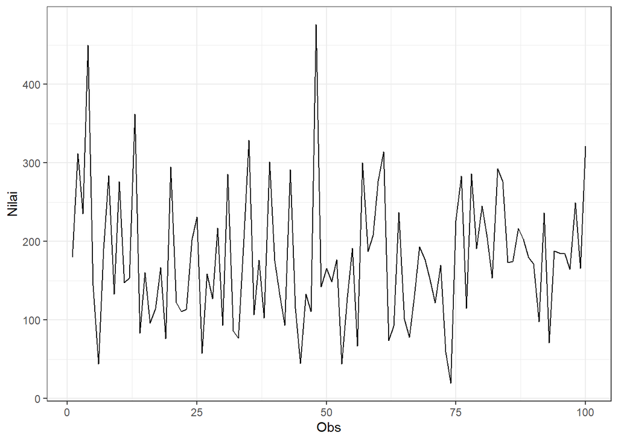

```r
plot_fmcg <- fmcg.ts |> as_tsibble() |>
  ggplot(aes(x = index, y = value)) + geom_line() + theme_bw() +
  xlab("Obs") + ylab("Nilai")
plot_fmcg
```

```r
mean(fmcg.ts)
```

```
## [1] 177.7726
```

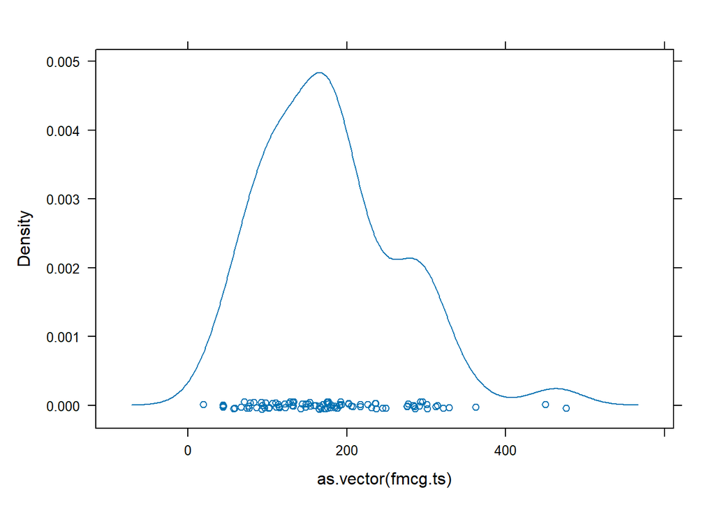

```r
lattice::densityplot(as.vector(fmcg.ts))
```

Kesimpulan yang dapat diambil dari plot time series di atas adalah secara visual data yang kita miliki sudah **stationer dalam rataan dan ragam** karena tidak terlihat adanya pola musiman atau tren yang jelas. **Namun**, untuk memastikan stasioneritas data, **kita perlu melakukan uji statistik lebih lanjut** seperti ADF (Augmented Dickey-Fuller) dan melihat ACF (Autocorrelation Function).

## 3 Plot **ACF**

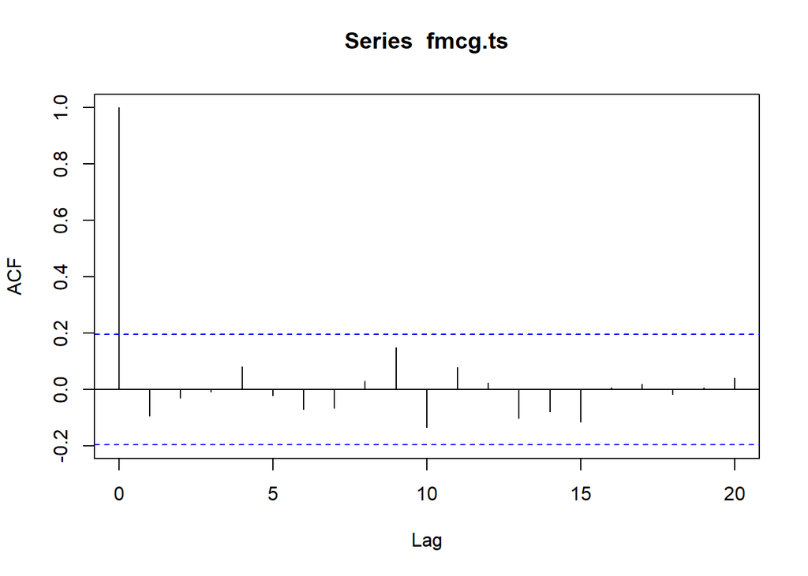

```r
acf(fmcg.ts)
```

Kesimpulan yang dapat diambil:

1. **Data kemungkinan sudah stationer** dalam rataan, hal ini dibuktikan dengan korelasi pada lag 1 yang **cut off** di dalam batas signifikan, tidak menurun perlahan seperti pada data non-stasioner.
2. **Tidak ada autokorelasi signifikan** yang tersisa pada sebagian besar lag, hal ini terlihat pada lag >=1 berada di dalam batas signifikan

## 4 Uji **ADF**

Uji ADF (Augmented Dickey–Fuller) adalah uji statistik yang digunakan untuk memeriksa apakah suatu deret waktu stasioner dalam rataan.

```r
tseries::adf.test(fmcg.ts)
```

```
##
##  Augmented Dickey-Fuller Test
##
## data:  fmcg.ts
## Dickey-Fuller = -4.7772, Lag order = 4, p-value = 0.01
## alternative hypothesis: stationary
```

Dari hasil uji ADF, p−value(0.01) lebih kecil dari taraf nyata 5% (0.05), maka kita Tolak H0. Artinya data **stationer dalam rataan.**

## 5 Plot Box-Cox

Selanjutnya akan dilakukan plot box-cox, karena data yang dipakai seluruhnya bernilai **positif**, sehingga **tidak diperlukan shifting.**

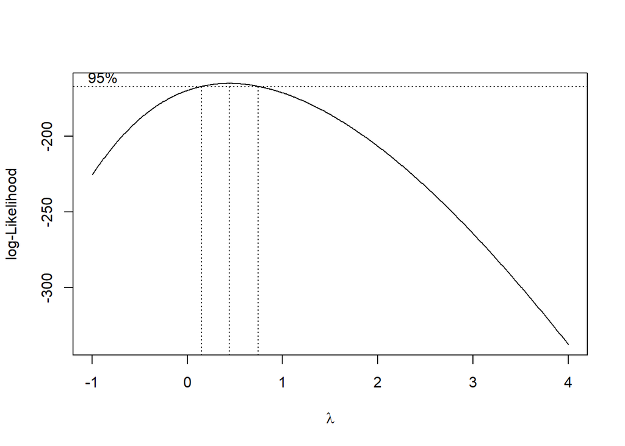

```r
# Box-Cox
library(MASS)

index_fmcg <- seq(1:length(fmcg.ts))

bc <- boxcox(
    fmcg.ts ~ index_fmcg,
    lambda = seq(-1, 4, by = 0.01)
)
```

```r
# nilai lambda optimum
lambda <- bc$x[which.max(bc$y)]
lambda
```

```
## [1] 0.44
```

```r
# selang kepercayaan 95% untuk lambda
ci_lambda <- bc$x[bc$y > max(bc$y) - 0.5 * qchisq(0.95, 1)]

# batas bawah dan atas
ci_lower <- min(ci_lambda)
ci_upper <- max(ci_lambda)

c(Batas_Bawah = ci_lower, Batas_Atas = ci_upper)
```

```
## Batas_Bawah  Batas_Atas
##        0.15        0.74
```

Hasil interpretasi:

1. Lambda optimum: 0,44
2. Selang kepercayaan: [0.15,0.74]

Karena **tidak** memuat nilai lambda = 1 di selang kepercayaan, maka **data tidak stationer dalam ragam.**

## 6 Kesimpulan

Kestationeran dalam data:

> Data **stationer dalam rataan** tapi **tidak stationer dalam ragam.** Untuk penanganan dilakukan **transformasi box-cox.**

## 7 Transformasi Box-Cox

```r
library(MASS)

#Transformasi Box-Cox (Menstabilkan Ragam)
# Menggunakan lambda = 0.44: Y_trans = Y ^ 0.44
lambda_optimum <- 0.44
fmcg.ts.trans <- fmcg.ts ^ lambda_optimum
```

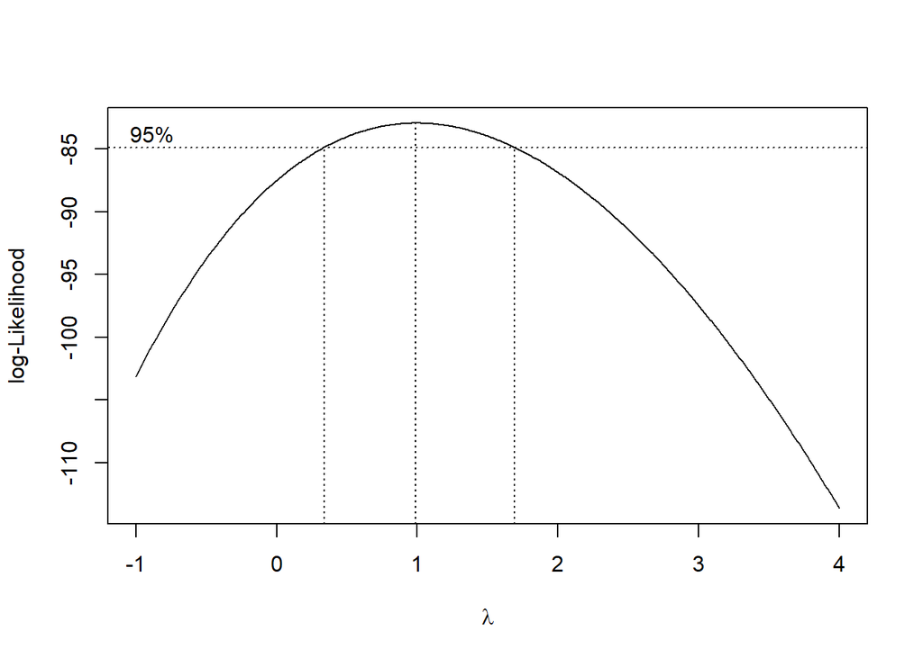

```r
index_fmcg <- seq(1:length(fmcg.ts))
model <- lm(daily_revenue ~ periode, data = fmcg)

bc <- boxcox(
    fmcg.ts.trans ~ index_fmcg,
    lambda = seq(-1, 4, by = 0.01)
)
```

```r
# Cari lambda optimal
lambda_opt <- bc$x[which.max(bc$y)]
lambda_opt
```

```
## [1] 0.99
```

```r
# Selang kepercayaan 95% untuk lambda
ci_lambda <- bc$x[bc$y > max(bc$y) - 0.5 * qchisq(0.95, 1)]

# Batas bawah dan batas atas
ci_lower <- min(ci_lambda)
ci_upper <- max(ci_lambda)

c(Batas_Bawah = ci_lower, Batas_Atas = ci_upper)
```

```
## Batas_Bawah  Batas_Atas
##        0.34        1.68
```

Hasil:

1. lambda optimal: 0.99
2. selang kepercayaan: [0.34,1.68]. Karena selang kepercayaan sudah **memuat nilai lambda = 1**, maka data sudah **stasioner dalam ragam**.

## 8 Cek Kestationeran dalam Rataan Data Setelah Transformasi dengan uji ADF

```r
tseries::adf.test(fmcg.ts.trans)
```

```
##
##  Augmented Dickey-Fuller Test
##
## data:  fmcg.ts.trans
## Dickey-Fuller = -4.8307, Lag order = 4, p-value = 0.01
## alternative hypothesis: stationary
```

Dari hasil uji ADF, p−value(0.01) lebih kecil dari taraf nyata 5% (0.05), maka kita Tolak H0. Artinya data **stationer dalam rataan.**

## 9 Kesimpulan data setelah dilakukan transformasi box-cox

Pada **keseluruhan data,**

1. data sudah **stationer dalam rataan (p-value 0.01 < 0.05)**
2. data sudah **stationer dalam ragam (selang kepercayaan memuat nilai 1)**